# Assignment 4 - Project the population

Demographic analysis

Villasenor-Derbez, J.C. & Faro, C

```r
suppressPackageStartupMessages({
  library(readr)
  library(tidyverse)
  library(reshape)
  library(popbio)
})
```

# Description of the demographic information

- Mortality: $Z = 1.39$ and $M = 0.63$ (Garbin & Castello, 2014)
- Fecundity: $a = -1.33354$, $b = 3.238$ (from FISHBASE)
- von Bertanalnffy growth parameters: $L_{inf} = 102.0$, $K = 0.55$, $t_0 = -0.02$ (Uchiyama & Struhsaker, 1981)

## Define demographic parameters

```r
# Define Von Bert parameters
# Garbin & Castello, 2014
# L_inf <- mean(c(80, 80, 87.12, 94, 97.9, 97.3, 112.34, 89.38, 92.5))
# K <- mean(c(0.32, 0.6, 0.22, 0.38, 0.14, 0.25, 0.14, 0.38, 0.16))

# Or from Us and Stiurskjgfas, 1981
L_inf <- 102
K <- 0.55
t_0 <- -0.02

# Just to be clear, we use L-inf  and to from Ushisomething, and K from the review

# Define fecundity parameters
# From fishbase http://www.fishbase.se/Reproduction/FecundityList.php?ID=107&GenusName=Katsuwonus&SpeciesName=pelamis&fc=416&StockCode=121
fec_a <- -1.33354
fec_b <- 3.238
# Define mortality
m <- 0.63
z <- 1.39
```

## Define the functions we will need

```r
# Convert length to age using von bertalanffy model, solving for t
length2age <- function(length, l_inf, K, t_o){
  age <- (1/-K)*(log(1-(length/L_inf))) + t_o
  return(age)
}

# Convert age to length using von bertalanffy model
age2length <- function(age, l_inf, K, t_o){
  length <- l_inf*(1-exp(-K*(age-t_o)))
  return(length)
}

#Convert length to fecundity (number of eggs)
fecundity <- function(length, a, b){
  f <- 10^(a+(b*log10(length*10)))
  return(f)
}
```

## Create the matrix

```r
A <- matrix(0, 14, 14) #initial empty matrix with all 0

# Populate matrix with mortality
for (i in 2:14){
  A[i,i-1] <- exp(-z)
}

# Populate matrix with fecundity
ages <- seq(0:13)-1
lengths <- age2length(ages, L_inf, K, t_0)
A[1,] <- fecundity(lengths, fec_a, fec_b)

A[is.na(A)] <- 0
A[2,1] <- 0.0000001
A[1,1] <- 0

colnames(A) <- ages
rownames(A) <- ages

knitr::kable(A, col.names = paste0("$a_{",ages,"}$"), row.names = F,
             caption = "Table I - Population matrix A. The inferior diagonal represents survivals, while the first row represents facundities.")
```

Table I - Population matrix A. The inferior diagonal represents survivals, while the first row represents facundities.

| $a_{0}$ | $a_{1}$ | $a_{2}$ | $a_{3}$ | $a_{4}$ | $a_{5}$ | $a_{6}$ | $a_{7}$ | $a_{8}$ | $a_{9}$ | $a_{10}$ | $a_{11}$ | $a_{12}$ | $a_{13}$ |
| --- | --- | --- | --- | --- | --- | --- | --- | --- | --- | --- | --- | --- | --- |
| 0e+00 | 1.657256e+07 | 7.026737e+07 | 1.294406e+08 | 1.758241e+08 | 2.072322e+08 | 2.270120e+08 | 2.389980e+08 | 2.461086e+08 | 2.502768e+08 | 2.527038e+08 | 2.541114e+08 | 2.549259e+08 | 255396708 |
| 1e-07 | 0.000000e+00 | 0.000000e+00 | 0.000000e+00 | 0.000000e+00 | 0.000000e+00 | 0.000000e+00 | 0.000000e+00 | 0.000000e+00 | 0.000000e+00 | 0.000000e+00 | 0.000000e+00 | 0.000000e+00 | 0 |
| 0e+00 | 2.490753e-01 | 0.000000e+00 | 0.000000e+00 | 0.000000e+00 | 0.000000e+00 | 0.000000e+00 | 0.000000e+00 | 0.000000e+00 | 0.000000e+00 | 0.000000e+00 | 0.000000e+00 | 0.000000e+00 | 0 |
| 0e+00 | 0.000000e+00 | 2.490753e-01 | 0.000000e+00 | 0.000000e+00 | 0.000000e+00 | 0.000000e+00 | 0.000000e+00 | 0.000000e+00 | 0.000000e+00 | 0.000000e+00 | 0.000000e+00 | 0.000000e+00 | 0 |
| 0e+00 | 0.000000e+00 | 0.000000e+00 | 2.490753e-01 | 0.000000e+00 | 0.000000e+00 | 0.000000e+00 | 0.000000e+00 | 0.000000e+00 | 0.000000e+00 | 0.000000e+00 | 0.000000e+00 | 0.000000e+00 | 0 |
| 0e+00 | 0.000000e+00 | 0.000000e+00 | 0.000000e+00 | 2.490753e-01 | 0.000000e+00 | 0.000000e+00 | 0.000000e+00 | 0.000000e+00 | 0.000000e+00 | 0.000000e+00 | 0.000000e+00 | 0.000000e+00 | 0 |
| 0e+00 | 0.000000e+00 | 0.000000e+00 | 0.000000e+00 | 0.000000e+00 | 2.490753e-01 | 0.000000e+00 | 0.000000e+00 | 0.000000e+00 | 0.000000e+00 | 0.000000e+00 | 0.000000e+00 | 0.000000e+00 | 0 |
| 0e+00 | 0.000000e+00 | 0.000000e+00 | 0.000000e+00 | 0.000000e+00 | 0.000000e+00 | 2.490753e-01 | 0.000000e+00 | 0.000000e+00 | 0.000000e+00 | 0.000000e+00 | 0.000000e+00 | 0.000000e+00 | 0 |
| 0e+00 | 0.000000e+00 | 0.000000e+00 | 0.000000e+00 | 0.000000e+00 | 0.000000e+00 | 0.000000e+00 | 2.490753e-01 | 0.000000e+00 | 0.000000e+00 | 0.000000e+00 | 0.000000e+00 | 0.000000e+00 | 0 |
| 0e+00 | 0.000000e+00 | 0.000000e+00 | 0.000000e+00 | 0.000000e+00 | 0.000000e+00 | 0.000000e+00 | 0.000000e+00 | 2.490753e-01 | 0.000000e+00 | 0.000000e+00 | 0.000000e+00 | 0.000000e+00 | 0 |
| 0e+00 | 0.000000e+00 | 0.000000e+00 | 0.000000e+00 | 0.000000e+00 | 0.000000e+00 | 0.000000e+00 | 0.000000e+00 | 0.000000e+00 | 2.490753e-01 | 0.000000e+00 | 0.000000e+00 | 0.000000e+00 | 0 |
| 0e+00 | 0.000000e+00 | 0.000000e+00 | 0.000000e+00 | 0.000000e+00 | 0.000000e+00 | 0.000000e+00 | 0.000000e+00 | 0.000000e+00 | 0.000000e+00 | 2.490753e-01 | 0.000000e+00 | 0.000000e+00 | 0 |
| 0e+00 | 0.000000e+00 | 0.000000e+00 | 0.000000e+00 | 0.000000e+00 | 0.000000e+00 | 0.000000e+00 | 0.000000e+00 | 0.000000e+00 | 0.000000e+00 | 0.000000e+00 | 2.490753e-01 | 0.000000e+00 | 0 |
| 0e+00 | 0.000000e+00 | 0.000000e+00 | 0.000000e+00 | 0.000000e+00 | 0.000000e+00 | 0.000000e+00 | 0.000000e+00 | 0.000000e+00 | 0.000000e+00 | 0.000000e+00 | 0.000000e+00 | 2.490753e-01 | 0 |

## Build a population vector

```r
load("size_dist_1980.RData") #This is the n-vector for 1980, loads it to a vector called n

n <- n %>% {
  .$N}%>%
  c(rep(0, times = 8))

n_0 <- sum(A[1, 2:14]*n, na.rm = T)

n <- c(n_0, n)

n
```

```
##  [1] 2.562588e+19 8.674537e+06 3.136387e+11 2.711014e+10 4.391505e+08
##  [6] 3.880114e+06 0.000000e+00 0.000000e+00 0.000000e+00 0.000000e+00
## [11] 0.000000e+00 0.000000e+00 0.000000e+00 0.000000e+00
```

## Project the population

We projected the population, stratified by ages, for 30 years in the future (Figure 1). The population seems to have a positive trend, which shows the population is increasing. Note how one-year olds achieve a population size of log(N) = 40 by year 22 (dashed lines). We will use this reference point when comparing with the management intervention.

```r
project <- popbio::pop.projection(A, n, 30)
```

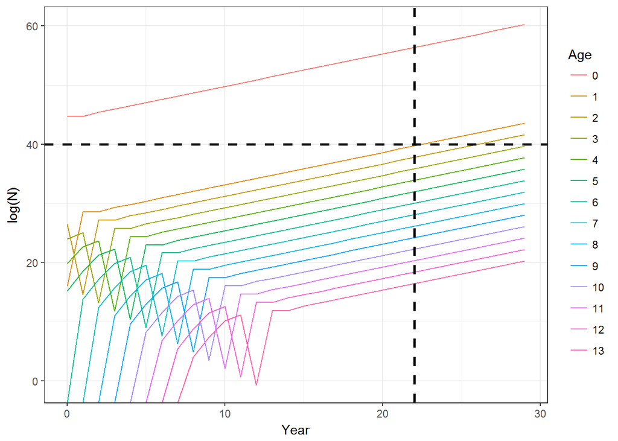

Figure 1 - Population size through time, represented by ages.

```r
pop <- project$stage.vectors %>%
  as.data.frame() %>%
  mutate(Age = as.factor(seq(0:13)-1)) %>%
  gather(Year, N, -Age) %>%
  mutate(Year = as.numeric(as.character(Year))) %>%
  select(Year, Age, N)

ggplot(pop, aes(x = Year, y = log(N), color = Age)) +
  geom_line() +
  theme_bw() +
  geom_hline(yintercept = 40, color = "black", linetype = "dashed", size = 1) +
  geom_vline(xintercept = 22, color = "black", linetype = "dashed", size = 1)
```

## Minimum catch size

This time we projected the population for 30 years in the future with a management intervention on the minimum size of capture (Figure 2). Our projection assumes total compliance on the intervention, which means the fishing pressure is equal to 0. Therefore, the total mortality (Z) is equal to the natural mortality (M) for individuals of age 1. By protecting individuals of age 1 (the age at which they reach maturity), we observe a faster recovery in the fishery. This can be observed by comparing the log(N) = 40 at year 22, which is now reached at year 18 for one-year olds. Additionally, in the context of the entire stock, Figure 3 shows that with the management intervention total skipjack population recovers faster.

```r
A_min <- A

A_min[3,2] <- exp(-m)

knitr::kable(A_min, col.names = paste0("$a_{",ages,"}$"), row.names = F, caption = "Table I - Population matrix A, modifying mortality of age 1 organisms. The inferior diagonal represents survivals, while the first row represents facundities.")
```

Table I - Population matrix A, modifying mortality of age 1 organisms. The inferior diagonal represents survivals, while the first row represents facundities.

| $a_{0}$ | $a_{1}$ | $a_{2}$ | $a_{3}$ | $a_{4}$ | $a_{5}$ | $a_{6}$ | $a_{7}$ | $a_{8}$ | $a_{9}$ | $a_{10}$ | $a_{11}$ | $a_{12}$ | $a_{13}$ |
| --- | --- | --- | --- | --- | --- | --- | --- | --- | --- | --- | --- | --- | --- |
| 0e+00 | 1.657256e+07 | 7.026737e+07 | 1.294406e+08 | 1.758241e+08 | 2.072322e+08 | 2.270120e+08 | 2.389980e+08 | 2.461086e+08 | 2.502768e+08 | 2.527038e+08 | 2.541114e+08 | 2.549259e+08 | 255396708 |
| 1e-07 | 0.000000e+00 | 0.000000e+00 | 0.000000e+00 | 0.000000e+00 | 0.000000e+00 | 0.000000e+00 | 0.000000e+00 | 0.000000e+00 | 0.000000e+00 | 0.000000e+00 | 0.000000e+00 | 0.000000e+00 | 0 |
| 0e+00 | 5.325918e-01 | 0.000000e+00 | 0.000000e+00 | 0.000000e+00 | 0.000000e+00 | 0.000000e+00 | 0.000000e+00 | 0.000000e+00 | 0.000000e+00 | 0.000000e+00 | 0.000000e+00 | 0.000000e+00 | 0 |
| 0e+00 | 0.000000e+00 | 2.490753e-01 | 0.000000e+00 | 0.000000e+00 | 0.000000e+00 | 0.000000e+00 | 0.000000e+00 | 0.000000e+00 | 0.000000e+00 | 0.000000e+00 | 0.000000e+00 | 0.000000e+00 | 0 |
| 0e+00 | 0.000000e+00 | 0.000000e+00 | 2.490753e-01 | 0.000000e+00 | 0.000000e+00 | 0.000000e+00 | 0.000000e+00 | 0.000000e+00 | 0.000000e+00 | 0.000000e+00 | 0.000000e+00 | 0.000000e+00 | 0 |
| 0e+00 | 0.000000e+00 | 0.000000e+00 | 0.000000e+00 | 2.490753e-01 | 0.000000e+00 | 0.000000e+00 | 0.000000e+00 | 0.000000e+00 | 0.000000e+00 | 0.000000e+00 | 0.000000e+00 | 0.000000e+00 | 0 |
| 0e+00 | 0.000000e+00 | 0.000000e+00 | 0.000000e+00 | 0.000000e+00 | 2.490753e-01 | 0.000000e+00 | 0.000000e+00 | 0.000000e+00 | 0.000000e+00 | 0.000000e+00 | 0.000000e+00 | 0.000000e+00 | 0 |
| 0e+00 | 0.000000e+00 | 0.000000e+00 | 0.000000e+00 | 0.000000e+00 | 0.000000e+00 | 2.490753e-01 | 0.000000e+00 | 0.000000e+00 | 0.000000e+00 | 0.000000e+00 | 0.000000e+00 | 0.000000e+00 | 0 |
| 0e+00 | 0.000000e+00 | 0.000000e+00 | 0.000000e+00 | 0.000000e+00 | 0.000000e+00 | 0.000000e+00 | 2.490753e-01 | 0.000000e+00 | 0.000000e+00 | 0.000000e+00 | 0.000000e+00 | 0.000000e+00 | 0 |
| 0e+00 | 0.000000e+00 | 0.000000e+00 | 0.000000e+00 | 0.000000e+00 | 0.000000e+00 | 0.000000e+00 | 0.000000e+00 | 2.490753e-01 | 0.000000e+00 | 0.000000e+00 | 0.000000e+00 | 0.000000e+00 | 0 |
| 0e+00 | 0.000000e+00 | 0.000000e+00 | 0.000000e+00 | 0.000000e+00 | 0.000000e+00 | 0.000000e+00 | 0.000000e+00 | 0.000000e+00 | 2.490753e-01 | 0.000000e+00 | 0.000000e+00 | 0.000000e+00 | 0 |
| 0e+00 | 0.000000e+00 | 0.000000e+00 | 0.000000e+00 | 0.000000e+00 | 0.000000e+00 | 0.000000e+00 | 0.000000e+00 | 0.000000e+00 | 0.000000e+00 | 2.490753e-01 | 0.000000e+00 | 0.000000e+00 | 0 |
| 0e+00 | 0.000000e+00 | 0.000000e+00 | 0.000000e+00 | 0.000000e+00 | 0.000000e+00 | 0.000000e+00 | 0.000000e+00 | 0.000000e+00 | 0.000000e+00 | 0.000000e+00 | 2.490753e-01 | 0.000000e+00 | 0 |
| 0e+00 | 0.000000e+00 | 0.000000e+00 | 0.000000e+00 | 0.000000e+00 | 0.000000e+00 | 0.000000e+00 | 0.000000e+00 | 0.000000e+00 | 0.000000e+00 | 0.000000e+00 | 0.000000e+00 | 2.490753e-01 | 0 |

```r
project_min <- popbio::pop.projection(A_min, n, 30)
```

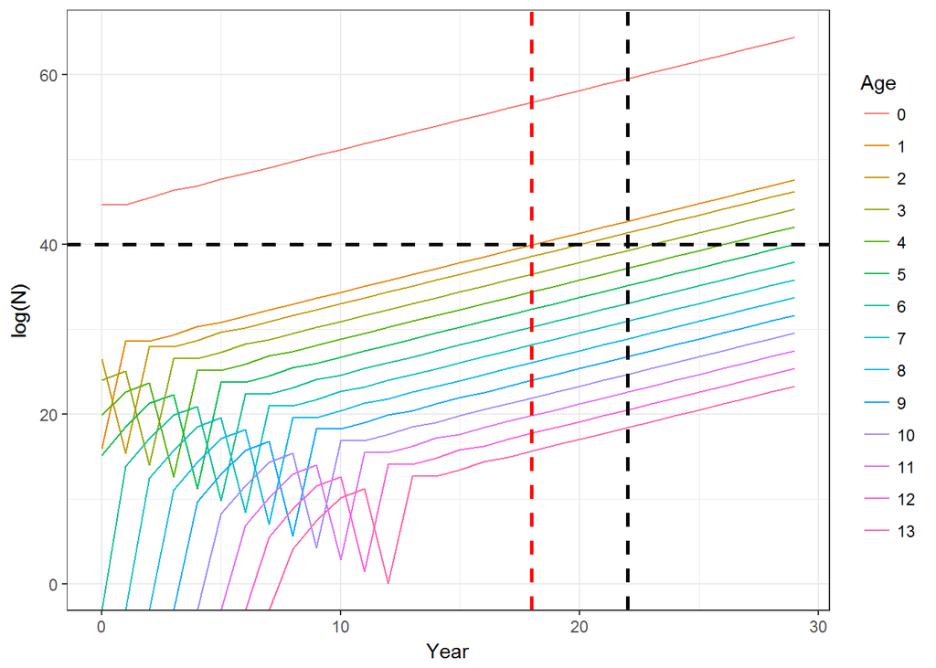

Figure 2 - Population size through time, represented by ages.

```r
pop <- project_min$stage.vectors %>%
  as.data.frame() %>%
  mutate(Age = as.factor(seq(0:13)-1)) %>%
  gather(Year, N, -Age) %>%
  mutate(Year = as.numeric(as.character(Year))) %>%
  select(Year, Age, N)

ggplot(pop, aes(x = Year, y = log(N), color = Age)) +
  geom_line() +
  theme_bw() +
  geom_hline(yintercept = 40, color = "black", linetype = "dashed", size = 1) +
  geom_vline(xintercept = 22, color = "black", linetype = "dashed", size = 1) +
  geom_vline(xintercept = 18, color = "red", linetype = "dashed", size = 1)
```

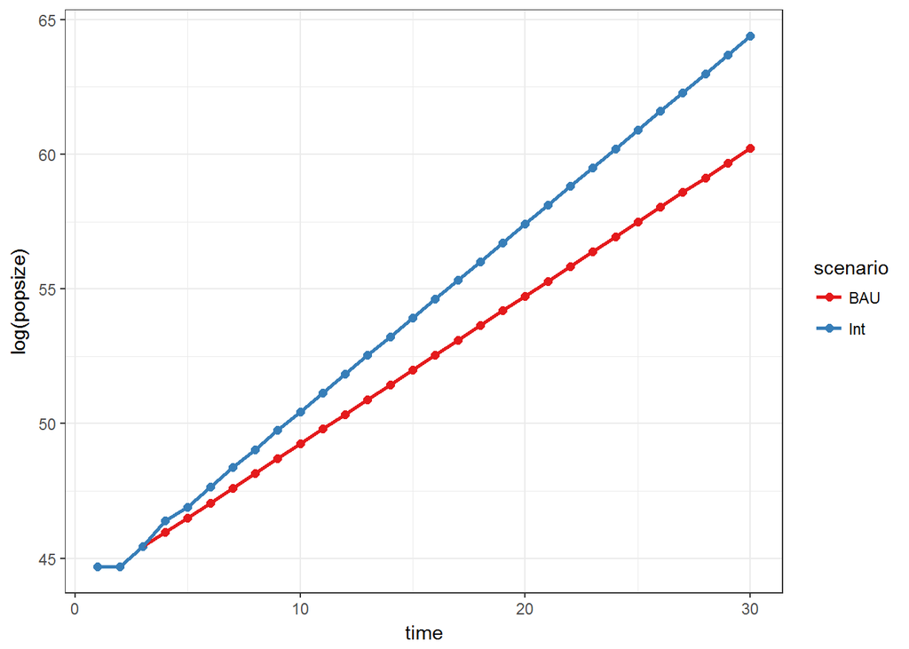

Figure 3 - Total population size through time.

```r
tot1 <- project$pop.sizes
tot2 <- project_min$pop.sizes
time <- seq(1:30)

data.frame(time, BAU = tot1, Int = tot2) %>%
  gather(scenario, popsize, -time) %>%
  ggplot(aes(x = time, y = log(popsize), color = scenario)) +
  geom_point(size = 2) +
  geom_line(size = 1) +
  theme_bw() +
  scale_color_brewer(palette = "Set1")
```